# Customer Segmentation using RFM analysis

## Overview

One way to retain customers is to increase customer satisfaction, by providing services following customer expectations and needs. Every customer must have different characteristics. therefore, we need to identify the characteristics of each customer and combine them in each group (customer segmentation) to make the right decisions in retaining customers.

In this project, I will use RFM to segment customers.

RFM stands for Recency, Frequency, and Monetary value, each corresponding to some key of customer behavior.

- Recency — How recently did the customer purchase?
- Frequency — How often do they purchase?
- Monetary Value — How much do they spend?

```python
import pandas as pd
```

### Download the data

All the data is downloaded from Kaggle.com

```python
dataset = pd.read_csv('sales_data_sample.csv',encoding='unicode_escape')
```

### Data Understanding

```python
#number of row and column
dataset.shape
```

```
(2823, 25)
```

```python
#show first row
dataset.head()
```

|  | ORDERNUMBER | QUANTITYORDERED | PRICEEACH | ORDERLINENUMBER | SALES | ORDERDATE | STATUS | QTR_ID | MONTH_ID | YEAR_ID | ... | ADDRESSLINE1 | ADDRESSLINE2 | CITY | STATE | POSTALCODE | COUNTRY | TERRITORY | CONTACTLASTNAME | CONTACTFIRSTNAME | DEALSIZE |
| --- | --- | --- | --- | --- | --- | --- | --- | --- | --- | --- | --- | --- | --- | --- | --- | --- | --- | --- | --- | --- | --- |
| 0 | 10107 | 30 | 95.70 | 2 | 2871.00 | 2/24/2003 0:00 | Shipped | 1 | 2 | 2003 | ... | 897 Long Airport Avenue | NaN | NYC | NY | 10022 | USA | NaN | Yu | Kwai | Small |
| 1 | 10121 | 34 | 81.35 | 5 | 2765.90 | 5/7/2003 0:00 | Shipped | 2 | 5 | 2003 | ... | 59 rue de l'Abbaye | NaN | Reims | NaN | 51100 | France | EMEA | Henriot | Paul | Small |
| 2 | 10134 | 41 | 94.74 | 2 | 3884.34 | 7/1/2003 0:00 | Shipped | 3 | 7 | 2003 | ... | 27 rue du Colonel Pierre Avia | NaN | Paris | NaN | 75508 | France | EMEA | Da Cunha | Daniel | Medium |
| 3 | 10145 | 45 | 83.26 | 6 | 3746.70 | 8/25/2003 0:00 | Shipped | 3 | 8 | 2003 | ... | 78934 Hillside Dr. | NaN | Pasadena | CA | 90003 | USA | NaN | Young | Julie | Medium |
| 4 | 10159 | 49 | 100.00 | 14 | 5205.27 | 10/10/2003 0:00 | Shipped | 4 | 10 | 2003 | ... | 7734 Strong St. | NaN | San Francisco | CA | NaN | USA | NaN | Brown | Julie | Medium |

5 rows × 25 columns

```python
dataset.info()
```

```
<class 'pandas.core.frame.DataFrame'>
RangeIndex: 2823 entries, 0 to 2822
Data columns (total 25 columns):
 #   Column            Non-Null Count  Dtype
---  ------            --------------  -----
 0   ORDERNUMBER       2823 non-null   int64
 1   QUANTITYORDERED   2823 non-null   int64
 2   PRICEEACH         2823 non-null   float64
 3   ORDERLINENUMBER   2823 non-null   int64
 4   SALES             2823 non-null   float64
 5   ORDERDATE         2823 non-null   object
 6   STATUS            2823 non-null   object
 7   QTR_ID            2823 non-null   int64
 8   MONTH_ID          2823 non-null   int64
 9   YEAR_ID           2823 non-null   int64
```

[output cut: 17 more lines]

```python
#number of unique transaction
len(dataset.ORDERNUMBER.unique())
```

```
307
```

```python
#number of unique customer
len(dataset.CUSTOMERNAME.unique())
```

```
92
```

```python
# total amount of transaction
dataset.SALES.sum()
```

```
10032628.85
```

```python
#last date of transaction
dataset.ORDERDATE.max()
```

```
'9/9/2004 0:00'
```

## Data Preparation

```python
data=dataset[['CUSTOMERNAME','ORDERNUMBER','ORDERDATE','SALES']]
data.shape
```

```
(2823, 4)
```

#### A. Recency (How recently a customer has made a purchase)

```python
recency = data[['ORDERDATE','CUSTOMERNAME']]
recency.head()
```

|  | ORDERDATE | CUSTOMERNAME |
| --- | --- | --- |
| 0 | 2/24/2003 0:00 | Land of Toys Inc. |
| 1 | 5/7/2003 0:00 | Reims Collectables |
| 2 | 7/1/2003 0:00 | Lyon Souveniers |
| 3 | 8/25/2003 0:00 | Toys4GrownUps.com |
| 4 | 10/10/2003 0:00 | Corporate Gift Ideas Co. |

```python
#Checking the data for the number of unique values:
recency.apply(pd.Series.nunique)
```

```
ORDERDATE       252
CUSTOMERNAME     92
dtype: int64
```

```python
# change format data
recency['ORDERDATE'] = pd.to_datetime(recency.ORDERDATE)
```

```python
recency.head()
```

|  | ORDERDATE | CUSTOMERNAME |
| --- | --- | --- |
| 0 | 2003-02-24 | Land of Toys Inc. |
| 1 | 2003-05-07 | Reims Collectables |
| 2 | 2003-07-01 | Lyon Souveniers |
| 3 | 2003-08-25 | Toys4GrownUps.com |
| 4 | 2003-10-10 | Corporate Gift Ideas Co. |

```python
# now refers to the latest date available in the data
now = max(recency['ORDERDATE'])
```

```python
#group customers by Their last purchase
recency = recency.groupby(['CUSTOMERNAME']).max()
recency.head()
```

| CUSTOMERNAME | ORDERDATE |
| --- | --- |
| AV Stores, Co. | 2004-11-17 |
| Alpha Cognac | 2005-03-28 |
| Amica Models & Co. | 2004-09-09 |
| Anna's Decorations, Ltd | 2005-03-09 |
| Atelier graphique | 2004-11-25 |

```python
#recency refers to the time since the last purchase
recency_days = now - recency['ORDERDATE']
```

```python
recency_days = pd.DataFrame(recency_days)
recency_days.head()
```

| CUSTOMERNAME | ORDERDATE |
| --- | --- |
| AV Stores, Co. | 195 days |
| Alpha Cognac | 64 days |
| Amica Models & Co. | 264 days |
| Anna's Decorations, Ltd | 83 days |
| Atelier graphique | 187 days |

```python
recency = pd.DataFrame(recency_days['ORDERDATE'].astype('timedelta64[D]'))
recency.columns = ['RECENCY']
recency.head()

# --delta max transaction date - last transaction for each customer
```

| CUSTOMERNAME | RECENCY |
| --- | --- |
| AV Stores, Co. | 195.0 |
| Alpha Cognac | 64.0 |
| Amica Models & Co. | 264.0 |
| Anna's Decorations, Ltd | 83.0 |
| Atelier graphique | 187.0 |

#### B. Frequency (How often a customer makes a purchase)

```python
frequency = data[['CUSTOMERNAME', 'ORDERDATE']]
frequency.rename(columns={"ORDERDATE": "FREQUENCY"},inplace = True)
```

```python
frequency = frequency.groupby(['CUSTOMERNAME']).count()#.agg({'FREQUENCY': lambda x: len(x.count())})
frequency.head()
```

| CUSTOMERNAME | FREQUENCY |
| --- | --- |
| AV Stores, Co. | 51 |
| Alpha Cognac | 20 |
| Amica Models & Co. | 26 |
| Anna's Decorations, Ltd | 46 |
| Atelier graphique | 7 |

#### C. Monetary (How much money a customer spends on purchases)

```python
monetary = data[['CUSTOMERNAME', 'SALES']]
monetary.rename(columns={"SALES": "MONETARY"}, inplace=True)
```

```python
monetary.head()
```

|  | CUSTOMERNAME | MONETARY |
| --- | --- | --- |
| 0 | Land of Toys Inc. | 2871.00 |
| 1 | Reims Collectables | 2765.90 |
| 2 | Lyon Souveniers | 3884.34 |
| 3 | Toys4GrownUps.com | 3746.70 |
| 4 | Corporate Gift Ideas Co. | 5205.27 |

```python
monetary = monetary.groupby(['CUSTOMERNAME']).sum()
monetary.head()
```

| CUSTOMERNAME | MONETARY |
| --- | --- |
| AV Stores, Co. | 157807.81 |
| Alpha Cognac | 70488.44 |
| Amica Models & Co. | 94117.26 |
| Anna's Decorations, Ltd | 153996.13 |
| Atelier graphique | 24179.96 |

## Modeling

```python
rfm = pd.concat([recency, frequency, monetary], axis=1)
rfm.head()
```

| CUSTOMERNAME | RECENCY | FREQUENCY | MONETARY |
| --- | --- | --- | --- |
| AV Stores, Co. | 195.0 | 51 | 157807.81 |
| Alpha Cognac | 64.0 | 20 | 70488.44 |
| Amica Models & Co. | 264.0 | 26 | 94117.26 |
| Anna's Decorations, Ltd | 83.0 | 46 | 153996.13 |
| Atelier graphique | 187.0 | 7 | 24179.96 |

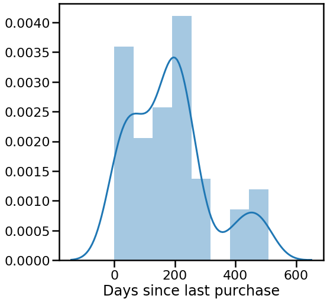

```python
# Plotting for the last day since the customer made a purchase:

import seaborn as sns
import matplotlib.pyplot as plt

plt.figure(figsize=(8,8))
sns.set_context("poster")
sns.distplot(rfm['RECENCY'])
plt.xlabel('Days since last purchase')
```

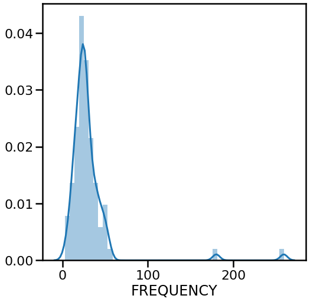

```python
# Plotting the number of times the customer has made a purchase:

plt.figure(figsize=(8,8))
sns.set_context("poster")
sns.distplot(rfm['FREQUENCY'])
```

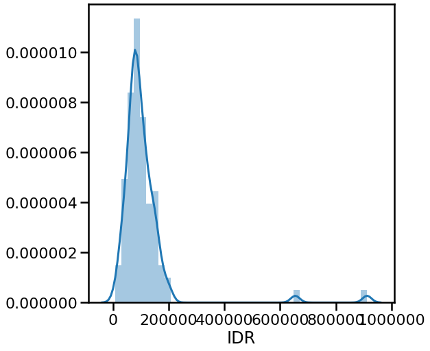

```python
# Plotting the total revenue that the particular customer brought in to the shop:

plt.figure(figsize=(8,8))
sns.set_context("poster")
sns.distplot(rfm['MONETARY'])
plt.xlabel('IDR')
```

```python
#Calculate the percentile values for each customer
rfm.quantile([.33, .66, 1], axis=0)
```

|  | RECENCY | FREQUENCY | MONETARY |
| --- | --- | --- | --- |
| 0.33 | 112.18 | 21.03 | 75254.3988 |
| 0.66 | 208.06 | 30.00 | 109089.0850 |
| 1.00 | 508.00 | 259.00 | 912294.1100 |

```python
RFMscores = rfm.copy()
RFMscores.shape
```

```
(92, 3)
```

```python
# Automate slice quantile for each variable
RFMscores['recency_score']    = pd.qcut(RFMscores['RECENCY'], 3, labels=[3, 2, 1])
RFMscores['frequency_score']  = pd.qcut(RFMscores['FREQUENCY'], 3, labels=[1, 2, 3])
RFMscores['monetary_score']   = pd.qcut(RFMscores['MONETARY'], 3, labels=[1, 2, 3])
```

```python
RFMscores = RFMscores.reset_index()
RFMscores
```

|  | CUSTOMERNAME | RECENCY | FREQUENCY | MONETARY | recency_score | frequency_score | monetary_score |
| --- | --- | --- | --- | --- | --- | --- | --- |
| 0 | AV Stores, Co. | 195.0 | 51 | 157807.81 | 2 | 3 | 3 |
| 1 | Alpha Cognac | 64.0 | 20 | 70488.44 | 3 | 1 | 1 |
| 2 | Amica Models & Co. | 264.0 | 26 | 94117.26 | 1 | 2 | 2 |
| 3 | Anna's Decorations, Ltd | 83.0 | 46 | 153996.13 | 3 | 3 | 3 |
| 4 | Atelier graphique | 187.0 | 7 | 24179.96 | 2 | 1 | 1 |
| ... | ... | ... | ... | ... | ... | ... | ... |
| 87 | Vida Sport, Ltd | 274.0 | 31 | 117713.56 | 1 | 3 | 3 |
| 88 | Vitachrome Inc. | 207.0 | 25 | 88041.26 | 2 | 2 | 2 |
| 89 | Volvo Model Replicas, Co | 193.0 | 19 | 75754.88 | 2 | 1 | 2 |
| 90 | West Coast Collectables Co. | 488.0 | 13 | 46084.64 | 1 | 1 | 1 |
| 91 | giftsbymail.co.uk | 211.0 | 26 | 78240.84 | 1 | 2 | 2 |

92 rows × 7 columns

```python
RFMscores['recency_score']    = RFMscores.recency_score.astype(int)
RFMscores['frequency_score']  = RFMscores.frequency_score.astype(int)
RFMscores['monetary_score']   = RFMscores.monetary_score.astype(int)
RFMscores['rfm_score'] = RFMscores['recency_score'].map(str) + RFMscores['frequency_score'].map(str) + RFMscores['monetary_score'].map(str)
```

```python
RFMscores.head()
```

|  | CUSTOMERNAME | RECENCY | FREQUENCY | MONETARY | recency_score | frequency_score | monetary_score | rfm_score |
| --- | --- | --- | --- | --- | --- | --- | --- | --- |
| 0 | AV Stores, Co. | 195.0 | 51 | 157807.81 | 2 | 3 | 3 | 233 |
| 1 | Alpha Cognac | 64.0 | 20 | 70488.44 | 3 | 1 | 1 | 311 |
| 2 | Amica Models & Co. | 264.0 | 26 | 94117.26 | 1 | 2 | 2 | 122 |
| 3 | Anna's Decorations, Ltd | 83.0 | 46 | 153996.13 | 3 | 3 | 3 | 333 |
| 4 | Atelier graphique | 187.0 | 7 | 24179.96 | 2 | 1 | 1 | 211 |

```python
#calculate sum rfm score
RFMscores['sum_rfm_score'] = RFMscores[['recency_score','frequency_score','monetary_score']].sum(axis=1)
```

```python
RFMscores.head()
```

|  | CUSTOMERNAME | RECENCY | FREQUENCY | MONETARY | recency_score | frequency_score | monetary_score | rfm_score | sum_rfm_score |
| --- | --- | --- | --- | --- | --- | --- | --- | --- | --- |
| 0 | AV Stores, Co. | 195.0 | 51 | 157807.81 | 2 | 3 | 3 | 233 | 8 |
| 1 | Alpha Cognac | 64.0 | 20 | 70488.44 | 3 | 1 | 1 | 311 | 5 |
| 2 | Amica Models & Co. | 264.0 | 26 | 94117.26 | 1 | 2 | 2 | 122 | 5 |
| 3 | Anna's Decorations, Ltd | 83.0 | 46 | 153996.13 | 3 | 3 | 3 | 333 | 9 |
| 4 | Atelier graphique | 187.0 | 7 | 24179.96 | 2 | 1 | 1 | 211 | 4 |

```python
RFMscores['sum_rfm_score'].describe()
```

```
count    92.000000
mean      5.978261
std       2.064766
min       3.000000
25%       4.000000
50%       6.000000
75%       8.000000
max       9.000000
Name: sum_rfm_score, dtype: float64
```

Name of segments:

- Champions : best customers, who bought most recently, most often, and spent the most.
- Loyal : recent customers who spent big amounts.
- Potential : High Potential to become Loyal customer segment.
- Average Customer : average recency, frequency, and monetary.
- New Customer : recent customers but are not frequent.
- Cannot Loose Them : customers who purchased often and spent big amounts, but haven’t purchased recently.
- Needs Attention : customers who used to visit and purchase quite often, but haven’t been visiting recently.
- Lost Customer : Lowest recency, frequency and monetary.

```python
#RFM Level name
def rfm_level(df):
    if df['rfm_score'] == '333':
        return 'Champions'
    elif ((df['rfm_score'] == '233') or (df['rfm_score'] =='323') or (df['rfm_score'] =='332')):
        return 'Loyal'
    elif ((df['rfm_score'] == '331') or (df['rfm_score'] =='322') or (df['rfm_score'] =='232') or (df['rfm_score'] =='223')):
        return 'Potential'
    elif ((df['rfm_score'] == '321') or (df['rfm_score'] =='231') or (df['rfm_score'] =='222') or (df['rfm_score'] =='213')):
        return 'Average Customer'
    elif ((df['rfm_score'] == '313') or (df['rfm_score'] =='312') or (df['rfm_score'] =='311')):
        return  'New Customer'
    elif ((df['rfm_score'] == '133') or (df['rfm_score'] =='132') or (df['rfm_score'] =='123')):
        return 'Cannot Loose Them'
    elif ((df['rfm_score'] == '111')):
        return 'Lost Customer'
    else:
        return 'Needs Attention'
RFMscores['rfm_Level'] = RFMscores.apply(rfm_level, axis=1)
```

```python
RFMscores['rfm_Level'] = RFMscores['rfm_Level'].astype('category')
RFMscores['rfm_Level'].cat.reorder_categories(['Champions', 'Loyal','Potential','Average Customer','New Customer','Cannot Loose Them','Needs Attention','Lost Customer'], inplace=True)
RFMscores['rfm_Level']
```

```
0                 Loyal
1          New Customer
2       Needs Attention
3             Champions
4       Needs Attention
            ...
87    Cannot Loose Them
88     Average Customer
89      Needs Attention
90        Lost Customer
91      Needs Attention
Name: rfm_Level, Length: 92, dtype: category
Categories (8, object): [Champions, Loyal, Potential, Average Customer, New Customer, Cannot Loose Them, Needs Attention, Lost Customer]
```

### Results & Insights

```python
#Who are our best customers?
RFMscores[RFMscores['rfm_Level']=='Champions'].sort_values('MONETARY', ascending=False).head(5)
```

|  | CUSTOMERNAME | RECENCY | FREQUENCY | MONETARY | recency_score | frequency_score | monetary_score | rfm_score | sum_rfm_score | rfm_Level |
| --- | --- | --- | --- | --- | --- | --- | --- | --- | --- | --- |
| 33 | Euro Shopping Channel | 0.0 | 259 | 912294.11 | 3 | 3 | 3 | 333 | 9 | Champions |
| 55 | Mini Gifts Distributors Ltd. | 2.0 | 180 | 654858.06 | 3 | 3 | 3 | 333 | 9 | Champions |
| 44 | La Rochelle Gifts | 0.0 | 53 | 180124.90 | 3 | 3 | 3 | 333 | 9 | Champions |
| 31 | Dragon Souveniers, Ltd. | 90.0 | 43 | 172989.68 | 3 | 3 | 3 | 333 | 9 | Champions |
| 81 | The Sharp Gifts Warehouse | 39.0 | 40 | 160010.27 | 3 | 3 | 3 | 333 | 9 | Champions |

```python
#Who are loyal customers?
#Customers with high frequency value

RFMscores[RFMscores['frequency_score'] >= 2 ].sort_values('FREQUENCY', ascending=False).head(5)
```

|  | CUSTOMERNAME | RECENCY | FREQUENCY | MONETARY | recency_score | frequency_score | monetary_score | rfm_score | sum_rfm_score | rfm_Level |
| --- | --- | --- | --- | --- | --- | --- | --- | --- | --- | --- |
| 33 | Euro Shopping Channel | 0.0 | 259 | 912294.11 | 3 | 3 | 3 | 333 | 9 | Champions |
| 55 | Mini Gifts Distributors Ltd. | 2.0 | 180 | 654858.06 | 3 | 3 | 3 | 333 | 9 | Champions |
| 6 | Australian Collectors, Co. | 183.0 | 55 | 200995.41 | 2 | 3 | 3 | 233 | 8 | Loyal |
| 44 | La Rochelle Gifts | 0.0 | 53 | 180124.90 | 3 | 3 | 3 | 333 | 9 | Champions |
| 0 | AV Stores, Co. | 195.0 | 51 | 157807.81 | 2 | 3 | 3 | 233 | 8 | Loyal |

```python
#Which customers are at the verge of churning?
#Customers who's recency value is low

RFMscores[RFMscores['recency_score'] == 1 ].sort_values('MONETARY', ascending=False).head(5)
```

|  | CUSTOMERNAME | RECENCY | FREQUENCY | MONETARY | recency_score | frequency_score | monetary_score | rfm_score | sum_rfm_score | rfm_Level |
| --- | --- | --- | --- | --- | --- | --- | --- | --- | --- | --- |
| 71 | Saveley & Henriot, Co. | 455.0 | 41 | 142874.25 | 1 | 3 | 3 | 133 | 7 | Cannot Loose Them |
| 24 | Corrida Auto Replicas, Ltd | 211.0 | 32 | 120615.28 | 1 | 3 | 3 | 133 | 7 | Cannot Loose Them |
| 87 | Vida Sport, Ltd | 274.0 | 31 | 117713.56 | 1 | 3 | 3 | 133 | 7 | Cannot Loose Them |
| 40 | Herkku Gifts | 270.0 | 29 | 111640.28 | 1 | 2 | 3 | 123 | 6 | Cannot Loose Them |
| 48 | Marta's Replicas Co. | 230.0 | 27 | 103080.38 | 1 | 2 | 2 | 122 | 5 | Needs Attention |

```python
#Who are lost customers?
#Customers who's recency, frequency as well as monetary values are low

RFMscores[RFMscores['rfm_score']=='111'].sort_values('MONETARY',ascending=False).head(5)
```

|  | CUSTOMERNAME | RECENCY | FREQUENCY | MONETARY | recency_score | frequency_score | monetary_score | rfm_score | sum_rfm_score | rfm_Level |
| --- | --- | --- | --- | --- | --- | --- | --- | --- | --- | --- |
| 29 | Diecast Collectables | 400.0 | 18 | 70859.78 | 1 | 1 | 1 | 111 | 3 | Lost Customer |
| 26 | Daedalus Designs Imports | 465.0 | 20 | 69052.41 | 1 | 1 | 1 | 111 | 3 | Lost Customer |
| 62 | Osaka Souveniers Co. | 413.0 | 20 | 67605.07 | 1 | 1 | 1 | 111 | 3 | Lost Customer |
| 18 | Classic Gift Ideas, Inc | 229.0 | 21 | 67506.97 | 1 | 1 | 1 | 111 | 3 | Lost Customer |
| 8 | Auto Assoc. & Cie. | 232.0 | 18 | 64834.32 | 1 | 1 | 1 | 111 | 3 | Lost Customer |

```python
RFMscores.to_csv(r'E:\rfm_customers.csv', index = False, header=True)
```

```python
rfm_level_summary = RFMscores.groupby('rfm_Level').agg({'RECENCY': 'sum','FREQUENCY': 'sum','MONETARY': ['sum', 'count']}).round(1)
print(rfm_level_summary)
```

```
                  RECENCY FREQUENCY   MONETARY
                      sum       sum        sum count
rfm_Level
Champions           623.0      1001  3600670.1    16
Loyal              1681.0       410  1456891.5    10
Potential           603.0       201   704481.7     7
Average Customer   1870.0       321  1097990.6    13
New Customer        438.0        98   374118.7     6
Cannot Loose Them  1210.0       133   492843.4     4
Needs Attention    4547.0       414  1461781.2    20
Lost Customer      5756.0       245   843851.7    16
```

## Conclusion

We can see that 65% revenue comes from Champions, Loyal and Needs Attention. We can give business recommendations based on RFM scores.

Here's a suggested strategy for each segment:

- Champions : Reward these customers. They will help promote our brand.
- Loyal : Recommend related products to upsell them and help them become Champions.
- Potential : Offer membership or recommend other products.
- Average Customer : Build good relationships.
- New Customer : Start building relationships with these customers.
- Cannot Loose Them : Offer relevant promotions and helpful products.
- Needs Attention : Send relevant promotions to reconnect. Recommend popular products/renewals at discount.
- Lost Customer : Bring them back with relevant promotions, and run surveys to find out what went wrong.